# numpy Class_Project_2a_Princess_Solution

# The Princess Challenge

## Solution with Python Standard Library

## 1. Getting startet...one simulation

**100 princes (applicants)** ask for the Princess´ hand in marriage. The 100 princes can be ranked by quality from **1 (lowest quality)** to **100 (highest quality, the "Prince Charming")**. The Princess dates one prince after another (the **order is random**) and at the end of each Date, she has to **decide irrevocably**, whether to **dismiss** the prince or **select the prince as her husband**. Once she has selected one prince, the game stops.

The Princess is very **picky** and wants to **maximise the probability** of selecting Prince Charming, the **prince with quality 100**. All or nothing.

As the Princess is neither familiar with Python nor with math, she chooses the **following naive strategy**:

- The Princess group the **first 50 princes into a testgroup** and the **last 50 princes into a selectgroup**.
- She **dismisses all princes of the testgroup** and memorizes the **quality of the best prince** in the testgroup.
- In the **selectgroup**, she selects the **first prince**, that has a **higher quality than the best prince in the testgroup**.

Alright, let´s start coding, we assign

- **100** to the variable **size_applicants**
- **50** to the variable **size_testgroup**

```python
size_applicants = 100
size_testgroup = 50
```

Before we can simulate the random order of princes, we have to **import the "random" module** first...

```python
import random
```

First of all, let´s create a **list** with the **sorted order of 100 princes**.  
Therefore, create a **range()** object from **1 till 100 (both ends inclusive)** and then **transform** the range object into a **list**. Use the **variable size_applicants** as an **argument to the range() function**. Store the list in the variable **applicants_sorted**.

```python
applicants_sorted= list(range(1, size_applicants+1))
```

**Print** the list **applicants_sorted** and check whether your code gives the desired result (**integers from 1 till 100**).

```python
applicants_sorted
```

```
[1,
 2,
 3,
 4,
 5,
 6,
 7,
 8,
 9,
 10,
 11,
 12,
 13,
 14,
 15,
 16,
 17,
 18,
 19,
 20,
 21,
 22,
 23,
 24,
 25,
 26,
 27,
 28,
 29,
 30,
 31,
 32,
 33,
 34,
 35,
 36,
 37,
 38,
 39,
 40,
```

[output cut: 45 more lines]

```
 86,
 87,
 88,
 89,
 90,
 91,
 92,
 93,
 94,
 95,
 96,
 97,
 98,
 99,
 100]
```

Very Good! Now let´s **unsort our list** and create a **random order**.  
Therefore, create a **random sample of applicants_sorted** by passing **applicants_sorted** to the **function random.sample()**.  
As we want to **unsort/sample all 100 princes**, we also have to pass **size_applicants** as the **second argument** to the function random.sample().

```python
random.sample(applicants_sorted, size_applicants)
```

```
[100,
 69,
 4,
 70,
 7,
 74,
 14,
 23,
 60,
 31,
 57,
 64,
 5,
 95,
 22,
 42,
 39,
 19,
 56,
 71,
 82,
 83,
 96,
 76,
 81,
 38,
 18,
 94,
 16,
 17,
 80,
 61,
 50,
 8,
 34,
 2,
 29,
 59,
 45,
 25,
```

[output cut: 45 more lines]

```
 3,
 58,
 90,
 11,
 36,
 68,
 10,
 91,
 28,
 6,
 52,
 26,
 99,
 89,
 63]
```

**Check** the **randomly sorted list** and **run the above cell again** and again. In each run, you should get **different results**, right?

If we want to get **identical random results** in each run, we have to **set a random seed**.  
Pass **114 to random.seed()** and **randomly sample applicants_sorted** again. Store the result in the variable **applicants_unsorted**.

```python
random.seed(114)
applicants_unsorted= random.sample(applicants_sorted, size_applicants)
```

**Print applicants_unsorted** and check the **length with len()**. Should be **100**.  
The **first prince** has the quality ... **31**, right?

```python
applicants_unsorted
```

```
[31,
 73,
 13,
 44,
 86,
 32,
 81,
 80,
 7,
 20,
 67,
 68,
 87,
 90,
 38,
 75,
 9,
 69,
 48,
 97,
 14,
 12,
 60,
 51,
 15,
 89,
 39,
 82,
 85,
 56,
 59,
 30,
 62,
 29,
 43,
 74,
 98,
 63,
 6,
 71,
```

[output cut: 45 more lines]

```
 61,
 45,
 58,
 27,
 10,
 8,
 21,
 50,
 70,
 94,
 35,
 54,
 2,
 36,
 53]
```

```python
len(applicants_unsorted)
```

```
100
```

Alright, that works. Now let´s **slice** applicants_unsorted for the **testgroup**.  
Remember: The **first 50 princes** form the **testgroup**. The Princess **dates** and **dismisses all of them**.

- **Slice applicants_unsorted** with **square brackets** from the **first prince** until and inclusive the **50th prince**.
- Use the variable **size_testgroup** to slice.
- Assign the **variable testgroup** to the result.

```python
testgroup = applicants_unsorted[:size_testgroup]
```

**Print testgroup** and check the **number of princes** in the testgroup with **len()**. Should be **50**.

```python
#print testgroup
testgroup
```

```
[31,
 73,
 13,
 44,
 86,
 32,
 81,
 80,
 7,
 20,
 67,
 68,
 87,
 90,
 38,
 75,
 9,
 69,
 48,
 97,
 14,
 12,
 60,
 51,
 15,
 89,
 39,
 82,
 85,
 56,
 59,
 30,
 62,
 29,
 43,
 74,
 98,
 63,
 6,
 71,
 84,
 37,
 66,
 42,
 17,
 23,
 11,
 49,
 34,
 77]
```

```python
#check lenght of testgroup
len(testgroup)
```

```
50
```

Well done! Now let´s **search for the best prince** with the highest quality in the testgroup.  
Apply the function **max()** to testgroup and **store the best prince** in the variable **testgroup_best**. Then **print testgroup_best**.

```python
#get the best prince in testgroup (testgroup_best)
testgroup_best= max(testgroup)
```

```python
#print testgroup_best
testgroup_best
```

```
98
```

The **best prince** of the testgroup has the **quality** ... **98**, right?

Let´s also slice for the last 50 princes, that form the selectgroup. The Princess will choose her future husband from this group.

- **Slice applicants_unsorted** for the **last 50 princes**.
- Use **size_testgroup** within the square brackets.
- **Save** the result in the variable **selectgroup**

```python
selectgroup= applicants_unsorted[size_testgroup:]
```

**Print selectgroup** and check the **amount of princes** in the selectgroup, should be **50**, right?

```python
#print selectgroup
selectgroup
```

```
[64,
 100,
 22,
 72,
 52,
 78,
 92,
 91,
 99,
 4,
 93,
 28,
 47,
 18,
 57,
 96,
 40,
 16,
 46,
 76,
 3,
 5,
 19,
 33,
 25,
 95,
 79,
 24,
 41,
 55,
 26,
 65,
 83,
 88,
 1,
 61,
 45,
 58,
 27,
 10,
 8,
 21,
 50,
 70,
 94,
 35,
 54,
 2,
 36,
 53]
```

```python
#check length of selectgroup
len(selectgroup)
```

```
50
```

Well done! The **first prince** in the selectgroup has the **quality** ... **64**.

Now let´s **check for all princes in the selectgroup**, whether their **quality is higher** than the quality of the **best prince in the testgroup** (testgroup_best).

Therefore let´s **iterate over all elements** (=i) of selectgroup with a **for loop**.  
In each iteration, print:

- the quality of the prince (**i**)
- **testgroup_best**
- **boolean value** indicating, whether i is **greater than** testgroup_best  
  **Fill the gaps ---** !

```python
for i in selectgroup:
    print(i, testgroup_best, i > testgroup_best)
```

```
64 98 False
100 98 True
22 98 False
72 98 False
52 98 False
78 98 False
92 98 False
91 98 False
99 98 True
4 98 False
93 98 False
28 98 False
47 98 False
18 98 False
57 98 False
```

[output cut: 35 more lines]

The Princess selects the **very first prince in the selectgroup**, that has a **higher quality than testgroup_best**. **How many dates** will the Princess have in the selectgroup? Is the Princess successful and selects her one and only Prince Charming (**quality = 100**)?

The answer is ... she selects the **second prince** in the selectgroup and he is indeed **Prince Charming**!!!  
What a success and all without Python and math.

Alright, let´s **finetune** our code and we **combine for the loop with if/else statements**.

- We will store the prince, that the Princess selects, in the **variable selection**. And before the Princess starts to date the princes of the selectgroup, the **selection is set to 0** (no prince selected).
- Then the Princess dates one prince after another and she determines for each prince, **whether he is of higher quality** than testgroup_best or not.
- If he is of **higher quality**, the Princess **selects** him and the game stops (keyword **break**).
- If he is of **lower quality**, the Princess **dismisses** him (keyword **pass**) and dates the next prince.
- Finally **print selection** to display the **result** of her casting.

**Fill the gaps**!

```python
selection = 0
for i in selectgroup:
    if i > testgroup_best:
        selection = i
        break
    else:
        pass
print(selection)
```

```
100
```

And the result ... the Princess selects Prince Charming!!!

Let´s collect all code that we produced so far and **merge it into one cell**.  
Follow the instructions, copy and paste the code and run the cell!

```python
#seed(114)

#applicants_sorted = ---
#applicants_unsorted = ---
#testgroup = ---
#testgroup_best = ---
#selectgroup = ---

#selection = 0
#insert here for loop and if/else statement

#print out selection


random.seed(123)
applicants_sorted = list(range(1, size_applicants+1))
applicants_unsorted = random.sample(applicants_sorted, size_applicants)
testgroup = applicants_unsorted[:size_testgroup]
testgroup_best = max(testgroup)
selectgroup = applicants_unsorted[size_testgroup:]

selection = 0
for i in selectgroup:
    if i > testgroup_best:
        selection = i
        break
    else:
        pass
print(selection)
```

```
0
```

## 2. Getting probabilistic...with many simulations

Ok, let´s simulate our process many times and we start smoothly and set the number of simulations (**sims**) to **10**.

```python
sims = 10
```

**Copy** the code block from above and **add at the very top**:

- an **empty list called results** where you can store the result of each simulation (quality of selected prince)
- start another (outer) **for loop** to make 10 simulations/albums.

**Complete** the code and **fill the gaps**!

```python
results = []
random.seed(114)
for _ in range(sims):

    #random.seed(114)
    applicants_sorted = list(range(1, size_applicants+1))
    applicants_unsorted = random.sample(applicants_sorted, size_applicants)
    testgroup = applicants_unsorted[:size_testgroup]
    testgroup_best = max(testgroup)
    selectgroup = applicants_unsorted[size_testgroup:]

    selection = 0
    for i in selectgroup:
        if i > testgroup_best:
            selection = i
            break
        else:
            pass
    results.append(selection)
```

Let´s inspect the results... Do you notice anything strange?

```python
#print out results
results
```

```
[100, 0, 0, 99, 100, 99, 99, 95, 100, 99]
```

OK now we get **different results** and it looks like that either the Princess selects no prince at all or a very high quality prince!

Let´s further **increase simulations to 1000** to further reduce the impact of randomness (random noise). This is important when we later calculate statistics like mean, median, etc.  
Let´s continue. Copy the above code block and add **sims = 1000** at the very top and run the code.

```python
sims = 1000
results = []
random.seed(114)
for _ in range(sims):

    #random.seed(114)
    applicants_sorted = list(range(1, size_applicants+1))
    applicants_unsorted = random.sample(applicants_sorted, size_applicants)
    testgroup = applicants_unsorted[:size_testgroup]
    testgroup_best = max(testgroup)
    selectgroup = applicants_unsorted[size_testgroup:]

    selection = 0
    for i in selectgroup:
        if i > testgroup_best:
            selection = i
            break
        else:
            pass
    results.append(selection)
```

Make a sanity check and call **len(results)**. This should be **1000**!

```python
len(results)
```

```
1000
```

```python
results
```

```
[100,
 0,
 0,
 99,
 100,
 99,
 99,
 95,
 100,
 99,
 0,
 100,
 99,
 100,
 100,
 100,
 100,
 98,
 100,
 0,
 0,
 0,
 98,
 0,
 0,
 0,
 100,
 0,
 0,
 100,
 100,
 100,
 99,
 94,
 100,
 99,
 100,
 0,
 100,
 100,
```

[output cut: 945 more lines]

```
 100,
 100,
 99,
 98,
 100,
 0,
 0,
 0,
 0,
 100,
 100,
 100,
 100,
 100,
 100]
```

Perfect! In the next section we will **analyze** our 1000 results.

## 3. Analyzing results and calculating statistics

Perfect! Now it´s time to inspect our results in a more detailed way. Let´s calculate

- the Minimum using **min()** --> assign **Min**
- the Maximum using **max()** --> assign **Max**
- the Mean using **sum()/len()** --> assign **Mean**
- **how many times** we selected Prince Charming --> use the **count() method on results** and pass **size_applicants**(=100) as an argument. --> assign **Count**
- the **probability** of getting Prince Charming --> calculate **Count divided by sims** and assign the variable **prob_best**.
- **Fill the gaps!**

```python
Min = min(results)
Min
```

```
0
```

```python
Max = max(results)
Max
```

```
100
```

```python
Mean = sum(results)/len(results)
Mean
```

```
51.853
```

```python
Count = results.count(size_applicants)
Count
```

```
371
```

```python
prob_best = Count/sims
prob_best
```

```
0.371
```

The **probability of selecting Prince Charming** is round about **37 percent**. The **average** selected prince has a **quality of approx. 52**. But what could be more intuitive than **visualizing** our results to have a better understanding of the **frequency distribution** of results???  
Let´s first

- **import matplotlib.pyplot as plt**.
- we require **%matplotlib inline**
- and we set style to **"seaborn"** (**plt.style.use()**)

```python
#nothing to do, just run the cell!

import matplotlib.pyplot as plt
%matplotlib inline
plt.style.use("seaborn")
```

Ok, we should visualize our results with a **Histogram**, using **plt.hist()**.  
Therefore we set the parameter **bins** equal to **(Max-Min+1)** and add

- plt.figure(figsize = (12,6)) to increase the size of our figure
- x-axis label (**plt.xlabel()**) with **"Quality of selected prince (100 is best)"**
- y-axis label (**plt.ylabel()**) with **"Frequency"**
- title (**plt.title()**) with **"Prince Selection Frequency Distribution (Applicants = 100, Testgroup = 50, sims = 1000)"**. Set **fontsize** of title to **15**.

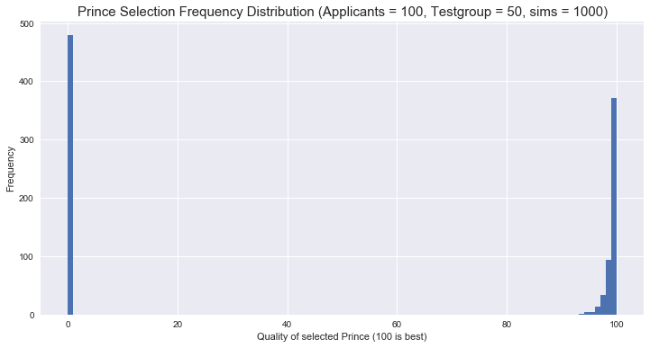

```python
plt.figure(figsize = (12,6))
plt.hist(results, bins = (Max-Min+1))
plt.xlabel("Quality of selected Prince (100 is best)")
plt.ylabel("Frequency")
plt.title("Prince Selection Frequency Distribution (Applicants = 100, Testgroup = 50, sims = 1000)", fontsize = 15)
plt.show()
```

Alright, this looks like the opposite of a bell shaped curve, where the most frequent events are in the middle!!! Here we have the highest frequencies at the left and right boundaries.

## 4. Automation by writing a Function

We can be proud of our project so far, but what if we want to change

- the **size_applicants** (number of applicants),
- the **size_testgroup** (size of testgroup) or
- the number of simulations (**sims**) we want to perform

in order to perform **more complex analysis** and **optimizations** to solve more advanced problems?

We should **automate** our project by **writing a function**!

Let´s define (**def**) a function called **Princess()** with the following **parameters** and **default values** inside the parentheses:

- **size_applicants** = 100
- **size_testgroup** = 50
- **sims** = 1000
- **seed** = 114

This is called the **Function Header**.

Add a return statement: **return** the string **"This is the result of Princess()"** in order to have a working function in the first place.

```python
def Princess(size_applicants = 100, size_testgroup = 50, sims = 1000,seed = 114 ):
    return "This is the result of Princess()"
```

**Call** the function with **default parameters** (simply **Princess()**) to check, if everything is working so far.

```python
Princess()
```

```
'This is the result of Princess()'
```

Perfect. So far we only have a Function Header and a more or less senseless return statement.  
Now we need to add the **Function Body**. Therefore, **copy** our **running code** from a few cells above and **paste** it as function body.  
We need to make a few **adjustments** to the Function Body:

- insert **parameter names** where required
- the function shall **return** the **probability of getting Prince Charming**, hence we need to **define and calculate** **prob_best**.

Finally, we want to **return** the **prob_best** as the function´s result.

**Complete** the cell below and **fill the gaps**!

```python
def Princess(size_applicants = 100, size_testgroup = 50, sims = 1000, seed = 114):

    results =[]
    random.seed(seed)
    for _ in range(sims):

        applicants_sorted = list(range(1, size_applicants+1))
        applicants_unsorted = random.sample(applicants_sorted, size_applicants)
        testgroup = applicants_unsorted[:size_testgroup]
        testgroup_best = max(testgroup)
        selectgroup = applicants_unsorted[size_testgroup:]

        selection = 0
        for i in selectgroup:
            if i > testgroup_best:
                selection = i
                break
            else:
                pass

        results.append(selection)
    prob_best = results.count(size_applicants)/sims

    return prob_best
```

Alright, let´s check if everything is **correct** and if we get the **same** prob_best as before (**0.371**). Call **Princess()** with default parameters.

```python
Princess()
```

```
0.371
```

Perfect, it works!  
Now let´s **variate** our parameters.  
Our picky Princess wants to **maximize the probability** of selecting **Prince Charming**. This **probability depends** on the **size of the testgroup** and will change when we variate the size of the testgroup. As an extreme case, assume that the **size of the testgroup is 99**. Hence, only **one prince will be in the selectgroup** and the probability, that the very last prince of all princes is Prince Charming is **1%** (=1/100, if our total number of applicants is 100).  
Alright, let´s **try and run our Princess() function** with some other testgroup sizes, e.g. **10** and **90** and let´s **inspect the results**.

```python
Princess(size_testgroup = 10)
```

```
0.231
```

```python
Princess(size_testgroup = 90)
```

```
0.097
```

OK, **both results** are **lower than with our default case** of size_testgroup = 50. So there might be a **Maximum** somewhere **between 10 and 90**...

Let´s simply check **all values between 1 and 100** for the parameter **size_testgroup**.  
Therefore, we create a **for loop** where we loop over a **range() object from 1 until 100** (both ends inclusive). And for each element (**size**) in our loop, we **print the element (size)** and the **result of our function Princess()**, where we pass the argument **size** for the parameter **size_testgroup**.

**Fill the gaps**!

```python
for size in range(1,101):
    print(size, Princess(size_testgroup= size))
```

```
1 0.048
2 0.07
3 0.102
4 0.123
5 0.15
6 0.169
7 0.19
8 0.211
9 0.218
10 0.231
11 0.249
12 0.258
13 0.272
14 0.274
15 0.279
```

[output cut: 85 more lines]

Alright, the **probability is increasing** until a testgroup size of approx. **38 or 39** and then the **probability decreases** again.

Let´s try to **visualize** this with a line plot with the **size of the testgroup on the x-axis** and the **probability of selecting Prince Charming on the y-axis**.  
Therefore:

- we create an **empty list** called **results_1000sims** where we **store all 100 results** of our iteration.
- we perform the **same iteration as in the cell above**, but instead of printing the results, we **append each result/each call of our Princess() function to the list results_1000sims**.
- **Fill the gaps**!

```python
results_1000sims = []
for size in range(1,101):
    results_1000sims.append(Princess(size_testgroup=size))
```

**Check** the number of elements in our list **results_1000sims** with **len()**. Should be **100**, right?

```python
len(results_1000sims)
```

```
100
```

Now we can **visualize** our results. **Fill the gaps**!

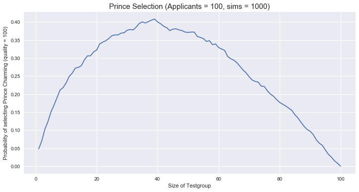

```python
import matplotlib.pyplot as plt
%matplotlib inline
plt.style.use("seaborn")


plt.figure (figsize = (12,6))
plt.plot(range(1,101), results_1000sims)
plt.xlabel("Size of Testgroup")
plt.ylabel("Probability of selecting Prince Charming (quality = 100)")
plt.title("Prince Selection (Applicants = 100, sims = 1000)", fontsize = 15)
plt.show()
```

There is indeed a **Maximum** somewhere in the **interval 35 to 40**. However, we can also see here the **impact of randomness**. We still have a lot of **random noise** in our graph which makes it **hard to really identify the Maximum**.  
We should **further increase the amount of simulations to 10,000**. In statistics, 10,000 is a commonly used number of simulations to reduce random noise significantly.

**Fill the gaps** and **recalculate/visualize with 10,000 simulations**.  
**Attention**: Your machine could have a tough time, you can **stop operations** by clicking on **Kernel (Toolbar) and then Interrupt**.

```python
results_10000sims = []
for size in range(1,101):
    results_10000sims.append(Princess(sims = 10000, size_testgroup=size))
```

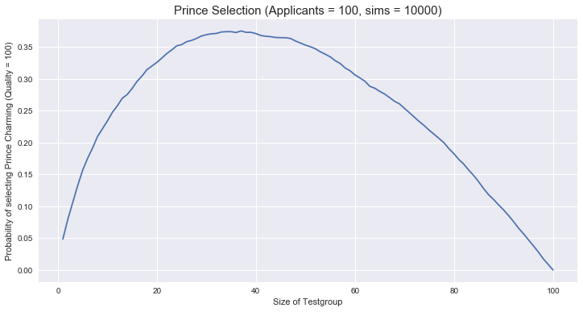

```python
plt.figure (figsize = (12,6))
plt.plot(range(1,101), results_10000sims)
plt.xlabel("Size of Testgroup")
plt.ylabel("Probability of selecting Prince Charming (Quality = 100)")
plt.title("Prince Selection (Applicants = 100, sims = 10000)", fontsize = 15)
plt.show()
```

Now the graph looks **much smoother**! So, to be more precise in our simulation we need to have **at least 10,000 simulations**!

Apparently, we will get the **maximum probability** with a testgroup size **between 35 and 40**. So, the **optimal testgroup size** should be **between 35% and 40%** of the total number of applicants.  
However, we make quite **large steps** by moving from 35 to 36 and then to 37 and so on. In order to get a **more precise result**, we should **increase the number of steps**. Therefore let´s **scale our analysis by 10** and let´s assume we have **1000 applicants** and the **optimal size of the testgroup** should be in the **range 350 to 400**.

**Fill the gaps** and **analyze** the result!

```python
for size in range(350, 401):
    print(size, Princess(sims = 10000, size_testgroup = size, size_applicants = 1000))
```

```
350 0.3599
351 0.3602
352 0.3608
353 0.3609
354 0.3615
355 0.3612
356 0.3617
357 0.3618
358 0.3615
359 0.3621
360 0.3618
361 0.3618
362 0.3618
363 0.3621
364 0.3619
```

[output cut: 36 more lines]

Here in our simulation, we achieve the **maximum probability** with a **testgroup size of 363 princes**. The mathematically **optimal testgroup size** should be somewhere **between 35.5% and 37.5%** of the total number of applicants.

Apparently **basic Python** has now **reached its limits** with regard to **speed and performance**. But before we move to **the NumPy package** to increase performance, we still want to **answer some more advanced questions** and variate our strategies. **100 applicants** and **1000 simulations** should do the job as well for our purposes.

But before let´s **measure the speed** of our Princess() function with **%timeit** and compare it later with NumPy performance. After the statement **%timeit**, call our function Princess() with **default** values for all parameters.

```python
%timeit Princess()
```

```
60.6 ms ± 122 µs per loop (mean ± std. dev. of 7 runs, 10 loops each)
```